# VisualEDA_Fetch_Analysis

## Distribution of Product Categories:

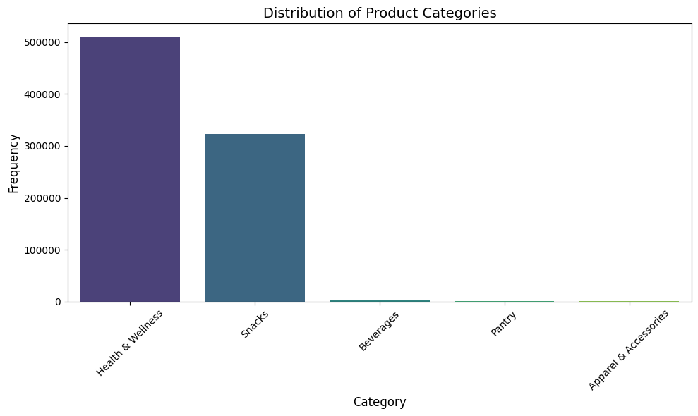

```python
# Plotting the distribution of CATEGORY_1
category_1_counts = products['CATEGORY_1'].head()

# Get the top 10 most frequent categories in CATEGORY_1
top_10_categories = products['CATEGORY_1'].value_counts().head(5)

# Assuming top_10_categories is a pandas Series with the index as the category and values as sales
plt.figure(figsize=(10,6))
sns.barplot(x=top_10_categories.index, y=top_10_categories.values, hue=top_10_categories.index, palette='viridis', legend=False)
plt.title('Distribution of Product Categories', fontsize=14)
plt.xlabel('Category', fontsize=12)
plt.ylabel('Frequency', fontsize=12)
plt.xticks(rotation=45)
plt.tight_layout()
plt.show()
```

Key Points:

Insights for Business:

1. **Focus on Popular Categories**:
   - Since **Health & Wellness** and **Snacks** are most common, these should be key areas to focus on for marketing and inventory.
2. **Opportunity in Underrepresented Categories**:
   - Categories like **Beverages** and **Dairy** might have untapped potential that could be explored for growth.
3. **Check Product Mix**:
   - The imbalance in categories suggests a closer look at the product mix might be needed to ensure more even distribution or better targeting of customers.

## Visualizing Sales Trends:

**Sales Trends Over Time (Date & Month)**

```
0   2024-08-21
1   2024-07-20
2   2024-08-18
3   2024-06-18
4   2024-07-04
Name: PURCHASE_DATE, dtype: datetime64[ns]
```

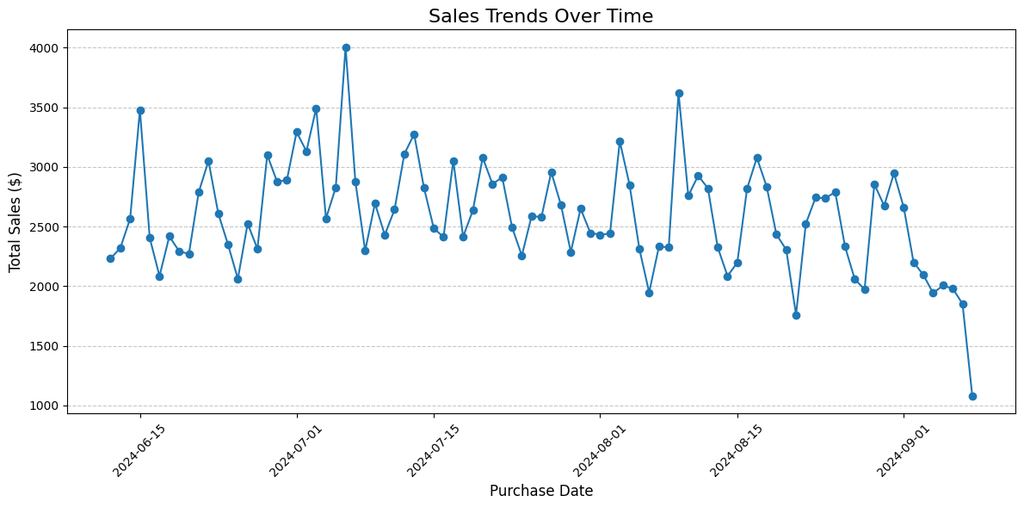

```python
# Ensure PURCHASE_DATE is in datetime format
transactions['PURCHASE_DATE'] = pd.to_datetime(transactions['PURCHASE_DATE'], errors='coerce')

# Check if the conversion was successful
print(transactions['PURCHASE_DATE'].head())

# Group by PURCHASE_DATE and sum FINAL_SALE to get daily sales totals
daily_sales = transactions.groupby(transactions['PURCHASE_DATE'].dt.date)['FINAL_SALE'].sum()

# Step 3: Plotting sales trends over time
plt.figure(figsize=(12, 6))  # Create a figure with specific dimensions
plt.plot(
    daily_sales.index,  # Use the index (dates) on the x-axis
    daily_sales.values,  # Use total sales on the y-axis
    marker="o",  # Use circle markers for data points
    linestyle="-",  # Use a solid line to connect points
)

plt.title("Sales Trends Over Time", fontsize=16)
plt.xlabel("Purchase Date", fontsize=12)
plt.ylabel("Total Sales ($)", fontsize=12)
plt.grid(axis="y", linestyle="--", alpha=0.7)
plt.xticks(rotation=45)
plt.tight_layout()
plt.show()
```

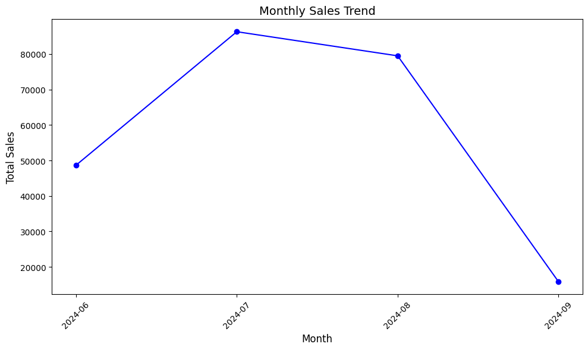

```python
# Grouping by month and year, summing up the 'FINAL_SALE' column
monthly_sales = transactions.groupby(transactions['PURCHASE_DATE'].dt.to_period("M"))['FINAL_SALE'].sum().reset_index()

# Plotting the sales trend over time
plt.figure(figsize=(10,6))
plt.plot(monthly_sales['PURCHASE_DATE'].astype(str), monthly_sales['FINAL_SALE'], marker='o', color='b')
plt.title("Monthly Sales Trend", fontsize=14)
plt.xlabel("Month", fontsize=12)
plt.ylabel("Total Sales", fontsize=12)
plt.xticks(rotation=45)
plt.tight_layout()
plt.show()
```

Key Points:

Insights for Business:

1. **Focus on High-Sales Days**:
   - Investigating the cause of the spikes in sales could help replicate successful strategies or promotions in the future.
2. **Address Declining Sales**:
   - The downward trend in sales towards the end of the period could indicate a potential seasonal dip, or it may suggest the need for business interventions to boost sales.
3. **Further Analysis**:
   - Analyzing the specific days of the week or linking with external factors (e.g., holidays or promotions) could provide more insight into the reasons for fluctuations.